# Forecasting And Time Series Analysis

Steve Elston

11/13/2022

# Why Are Time Series Useful?

- Data are often time-ordered
- Estimates 30% of data science problems include time series data
- Must use specific time series models

# Why Are Time Series Useful?

“It’s tough to make predictions, especially about the future!”

Karl Kristian Steincke, Danish politician, ca 1937

- **Demand forecasting:** Electricity production, Internet bandwidth, Traffic management, Inventory management, sales forecasting
- **Medicine:** Time dependent treatment effects, EKG, EEG
- **Engineering and Science:** Signal analysis, Analysis of physical processes
- **Capital markets and economics:** Seasonal unemployment, Price/return series, Risk analysis

# Why Are Time Series Data Different?

Models must account for time series behavior

- Most statistical and machine learning assume data samples are **independent identically distributed (iid)**
- But, this is not the case for time series data
- Time series values are correlated in time
- Time series data exhibit **Serial correlation**
  - Serial correlation of values
  - Serial correlation of errors
  - Violate iid assumptions of many statistical and ML Models  
    `

# Why Are Time Series Data Different

Examples of series correlation:

- Temperature forecasts, where the future values are correlated with the current values
- The opening price of a stock is correlated with the price at the previous close
- The daily sales volume of a product is correlated with the previous sales volume
- A medical patient’s blood pressure reading is correlated with the previous observations

# History of Time Series Analysis

Time series analysis have a long history  
- Recognized the serial dependency in time series data early on  
- Joseph Fourier and Siemon Poisson worked on time series problems in the early 19th Century

[figure not shown]

Joseph Fourier

# History of Time Series Analysis

Modern history of time series analysis started with George Udny Yule (1927) and Gilbert Walker (1931)

- Yule worked on sunspot time series
- Walker was attempting to forecast the tropical monsoon cycle
- Developed the **autoregressive (AR)** model to account for serial correlation of values
- The AR model is foundation of modern time series models

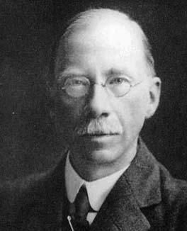

George Yule, time series pioneer

# History of Time Series Analysis

Mathematical prodigy, Norbert Weiner, invented filters for stochastic time series processes, starting in the 1920s

- Weiner’s filter theory is the basis of many time series filter methods
- Predictive filters for noisy signals; not discussed here
- Weiner process model for random walks is widely used

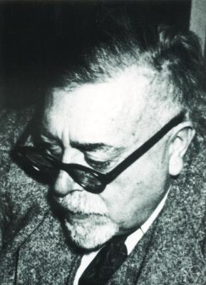

Norbert Weiner: Invented time series filters

# History of Time Series Analysis

George Box and Gwilym Jenkins fully developed a statistical theory of time series by extending the work of Yule and Walker in the 1950s and 1960s

- Extended the AR model to include **moving average (MA)** terms
- Included the **integrative term** to create the **ARIMA** model
- The ARIMA model is our focus

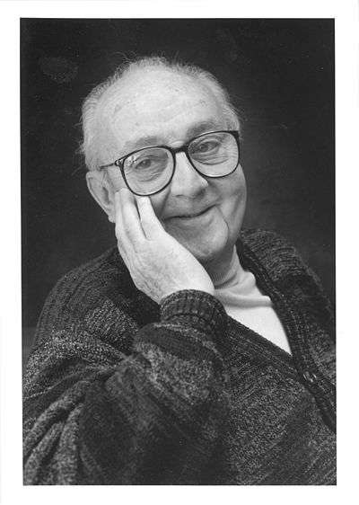

George EP Box created general time series model

[figure not shown]

Seminal time series analysis book

# History of Time Series Analysis

21st Century time series analysis

- Considerable research continues to expand the frontiers
- Bayesian time series models
  - [R bsts package](https://cran.r-project.org/web/packages/bsts/bsts.pdf) and [Python PyMC3](https://docs.pymc.io/api/distributions/timeseries.html)
- Long short term memory (LSTM) model
- Hidden Markov Models (HMMs) widely used
  - [Python Scikit Learn HMM](https://hmmlearn.readthedocs.io/en/stable/) or [R HMM package](https://www.rdocumentation.org/packages/HMM/versions/1.0)

# Software for Time Series Analysis

Most statistical packages have considerable time series modeling capability

- R time series analysis packages are wide and deep
  - Much leading edge research appears first in R packages
  - [CRAN Time Series Task View](https://cran.r-project.org/web/views/TimeSeries.html), maintained by Rob Hyndman, contains curated index to R time series packages
- Primary Python time series analysis package in [Statsmodels.tsa](https://www.statsmodels.org/stable/tsa.html)
- Bayesian time series models supported in [PyMC](https://www.pymc.io/welcome.html).
- Many newer Python time series packages packages, including:
  - [Darts package](https://unit8co.github.io/darts/) includes cutting edge methods like hierarcical models
  - [Facebook Kats](https://facebookresearch.github.io/Kats/) package - strong in forecasting including the [PROFIT model](https://facebook.github.io/prophet/)
  - [GrayKite](https://linkedin.github.io/greykite/docs/0.1.0/html/index.html) Linkedin’s forecasting package

# Fundamentals of Time Series

What are the fundamental properties of time series

- Representation and sampling
- White noise series
- Stationary time series
- Autocorrelation and partial autocorrelation
- Random walk series
- Trend
- Seasonal effects

# Time Series Representation

Time series are expressed as a time ordered sequence of values $(x_1, x_2, x_3, \ldots, x_n)$

- We work with **discrete samples** in time order
- In **regular time series** the sample interval $\Delta t$ is fixed
- Time measured from start of series $(0, \Delta t, 2 \Delta t, \ldots,n \Delta t)$
- Or, time measured within an **interval**, multiples of $\Delta t$
- Even continuous time processes are sampled in practice
  - Temperature
  - Pressure
  - Home price

# White Noise Series

**White noise series** are fundamental

- Values are **independent identically distributed (iid)** Normally distributed
- Can express values, $(w_1, w_2, w_3, \ldots, w_n)$, of a white noise series as:

$$X(t) = (w_1, w_2, w_3, \ldots, w_n)\\
where\\
w_t \sim N(0, \sigma^2)$$

- No serial correlation between values
  - There is no predictive information in a white noise series
  - We want the **residuals** of time series models to be white noise series

# White Noise Series

What does a white noise series look like?

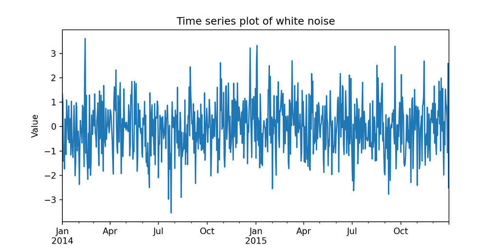

# White Noise Series

What does a white noise series look like?

- Each value is a sample is iid Normally distributed
- No trend

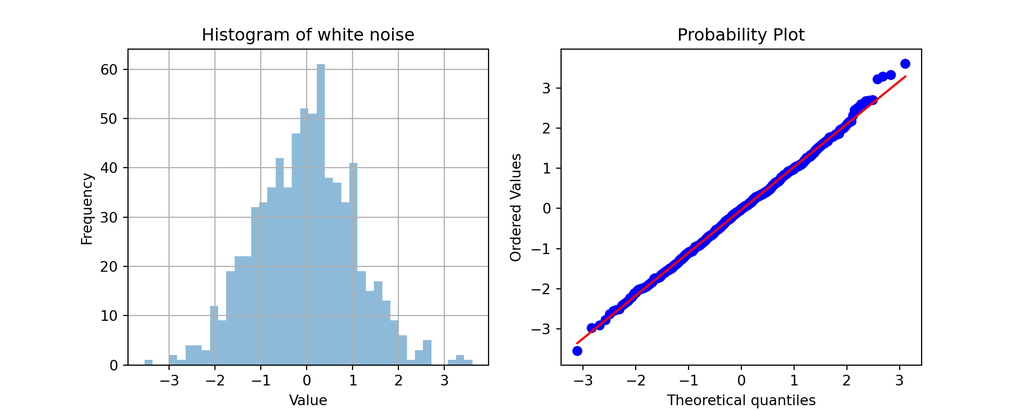

# Introduction to Stationary Time Series

A white noise series is **stationary**

- A stationary time series has statistical properties constant in time
- For example, a stationary time series has **constant mean and variance** over any sample interval
- Many time series models require stationarity
  - Often transform time series to make them stationary
  - More on this shortly

# Stationary Time Series

What tests can be used for stationarity?

- Plots
  - Qualitative
  - Nonstationarity from seasonality and trend are usually visible
- Hypothesis tests

# Autocorrelation Properties of White Noise Series

Can measure the correlation of a time series with itself

- The time series is correlated at different time offsets
- Each time step of offset is called a **lag**
- The **autocorrelation function (ACF)** is measured between the series and the series lagged in time

# Autocorrelation Properties of White Noise Series

We compute the autocorrelation at lag $k$:

$$\rho_k = \frac{\gamma_k}{n \sigma^2} =
\frac{1}{n \sigma^2} \sum_{t = 1}^N (y_{t} - \mu) \cdot (y_{t-k} -
\mu)$$
Where:
$$\begin{align}
k &= lag\\
y_t &= observaton\ at\ time\ t\\
\gamma_k &= covariance\ lag\ k\\
\mu &= mean\ of\ the\ series\\
\sigma^2 &= variance\ of\ the\ series = \frac{1}{n-1}\Sigma_{t =
1}^N (y_{t} - \mu) \cdot (y_{t} - \mu)
\end{align}$$

- Notice that for any series, $\rho_0 = 1$
- Autocorrelation at each lag has values in the range $-1.0 \ge \rho \ge 1.0$

# Autocorrelation Properties of White Noise Series

The **partial autocorrelation** is another important property of time series

- The **partial autocorrelation function (PACF)** is the residual autocorrelation once autocorrelation is accounted for
- To compute the partial autocorrelation to lag $k$:
  - Compute the autocorrelation to lag $k$
  - Remove the linearly predictable autocorrelation component of the time series
  - Compute the (partial) autocorrelation of the residual to lag $k$
- The 0 lag value of the partial autocorrelation is always 1.0

# Autocorrelation Properties of White Noise Series

What are the autocorrelation and partial autocorrelation properties of a white noise series?

- The autocorrelation and partial autocorrelation are 0 for all $k \gt 0$
- Autocorrelation plot shows value at each lag selected

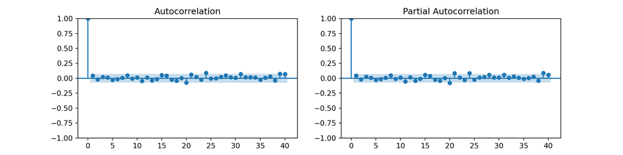

# Random Walk Time Series

Random walks are a commonly encountered properties of time series

- Change in value of random walk series at one time step:
  $$w_t = y_t - y_{t-1}$$
- The next value in the random walk is then:
  $$y_t = y_{t-1} + y_t$$

Or, with a little bit of algebra:

$$y_t = w_t + \sum_{i=0}^{t-1}
w_i$$

# Random Walk Time Series

Random walk is the sum of innovations:

$$y_t = w_t + \sum_{i=0}^{t-1}
w_i$$

- $w_i = $ the $i^{th}$ **innovation**
- $y_t=$ observation at time $t$
- A random walk is an **integrative process**; sum or integral of innovations

*Note:* innovations are referred to by other names:  
- **Shocks** in the stochastic process literature  
- **Returns** in financial analytics

# Random Walk Time Series

What does a random walk time series look like?

- Integrating innovations leads to a ‘drift-like’ behavior
- No actual trend; but can be considerable **drift**
- Random walk will eventually change apparent slope

Example with iid Normal innovations:

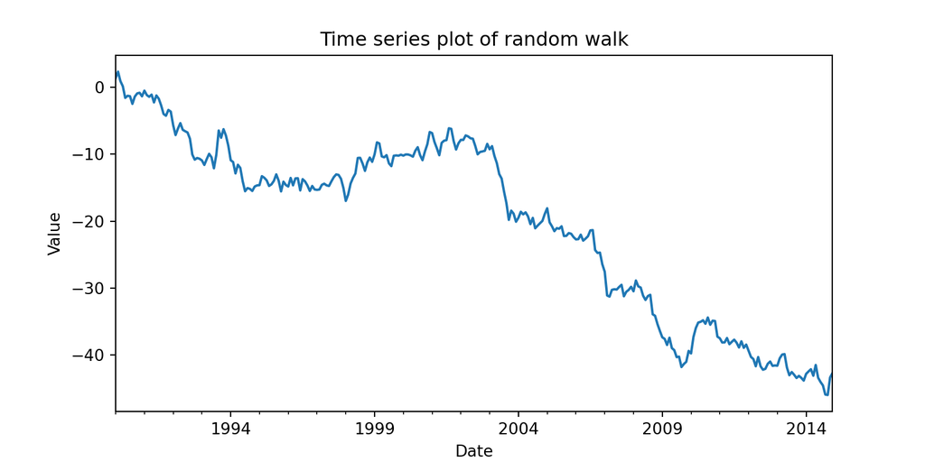

# Random Walk Time Series

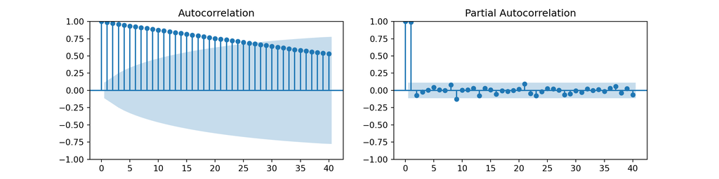

# Random Walk Time Series

Random walk series is not Normally distributed

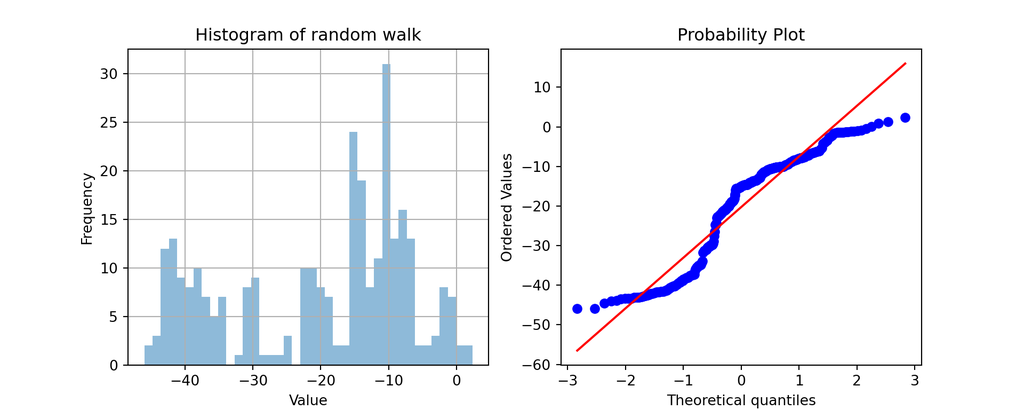

# Random Walk Time Series

Random walk time series are **non-stationary**

- Consider the **covariance** of a time series at lag $k$:

$$\gamma_k = Cov(y_t,
y_{t+k})$$

- For a random walk, the increase in covariance is **unbounded in time**:
  $$\gamma_k = Cov(y_t, y_{t+k}) = t \sigma^2
  \rightarrow \infty\ as\ t \rightarrow \infty$$
- Unbounded and time dependent variance make a random walk non-stationary

# Time Series With Trend

Many real-world time series have a long-term **trend**

- A trend is a long term change in the mean value of the time series
- Typically model trend as linear, polynomial, non-parametric splines, etc.
  - PROFIT algorithm uses **generalized additive model (GAM)**
- Consider an example of a white noise series with a linear trend

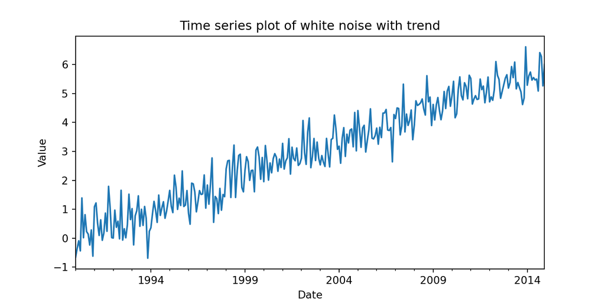

# Time Series With Trend

Trend models are not just strait lines

- Polynomial regression
- Piece-wise polynomial regression - e.g. splines
  - Used in [PROFIT algorithm](https://research.facebook.com/blog/2017/2/prophet-forecasting-at-scale/)
  - A **generalized additive model**
- [Local polynomial regression](https://en.wikipedia.org/wiki/Local_regression) - e.g. LOESS
  - Used in Statsmodels

# Time Series With Trend

Time series with trend are non-stationary

- Any time series with trend is non-stationary
  - Mean and variance are dependent of window used to compute them
- The distribution of even a white noise series with trend is non-Normal

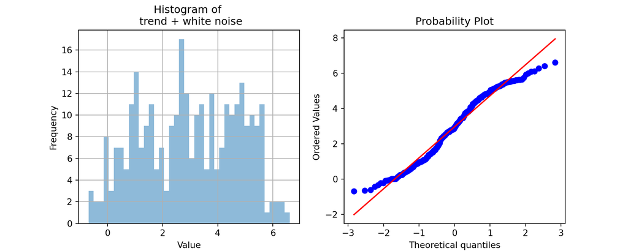

# Time Series With Trend

ACF and PACF are only properly defined for stationary series

- For non-stationary series, the ACF dies off slowly
  - Integrative innovations lead to long-term dependency
- The PACF dies off quickly with lag
- Example: ACF and PACF of the white noise series with trend

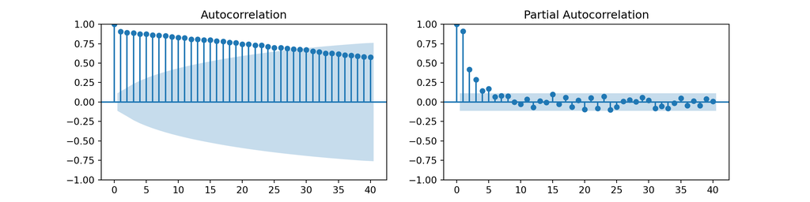

# Time Series With Seasonal Effects

Many (most?) real-world time series have **seasonal effect**

- A seasonal effect has a measurable effect that occurs periodically
- Examples of seasonal events include:
  - Day of the week
  - Last day of the month
  - Month of the year
  - Annual holiday
  - Option expiration date
  - Game day, e.g. Supper Bowl
  - Electrical impulses in a heart - EKG
  - Orbits of planets
  - $\ldots$
- Time series with seasonal effects are non-stationary
  - Mean and variance depends of sample window

# Time Series With Seasonal Effects

Use regression models for seasonal effects

- Simple regression model:
  - Coefficient for each interval in period; e.g. 12 coefficients for monthly effects
    - But simple approach leads to high variance estimates of coefficients for periodic behavior
  - Coefficient for specific effect - e.g. date of holiday
  - Good option for specific date behavior
- Basis function regression
  - [PROFIT algorithm](https://research.facebook.com/blog/2017/2/prophet-forecasting-at-scale/) uses Fourier basis functions
  - A **generalized additive model**

# Time Series With Seasonal Effects

Example of a time series with a seasonal effect

- A white noise series with trend and seasonal behavior
- The seasonal behavior is periodic

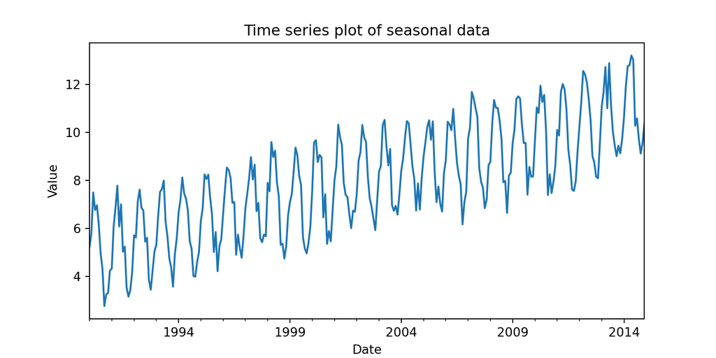

# Time Series Models

Many types of time series models; we only consider a few

- **Time series decomposition** into components
  - **STL** or [**seasonal-trend decomposition with LOESS**](https://www.statsmodels.org/dev/examples/notebooks/generated/stl_decomposition.html)
  - **MSTL** or [**multiple seasonal-trend decomposition with LOESS**](https://www.statsmodels.org/dev/examples/notebooks/generated/mstl_decomposition.html)
- **Exponential models**
  - Beyond the scope of our course
  - See [Chapter 8](https://otexts.com/fpp3/expsmooth.html) of Forecasting: Principles and Practice, Hyndman and Athanasopoulos, third edition, O Texts, 2021, for a in-depth discussion
- **ARIMA**: autoregressive integrative moving average
  - **AR** or **autoregressive component** accounts for serial correlation of values
  - **I** or **integrative component** component accounts for random walk and trend components
  - **MA** or **moving average component** accounts for serial correlation of errors

# Time Series Models

Many types of time series models

- **SARIMA**: seasonal autoregressive integrative moving average, adds seasonal components
  - **seasonal AR** accounts for serial correlation of seasonal values
  - **seasonal I** component accounts for random walk and trend of seasonal components
  - **seasonal MA** accounts for seasonal serial correlation of errors
- **SARIMAX: seasonal autoregressive integrative moving average with** exogenous variables**
  - Add effect of external factors
  - Example; effect of specific holiday
  - Example; effect arising from factors not incorporated in endogenous variable

# Time Series Decomposition

Two possible models for seasonal effects

- Goal, decompose the time series into its components
- The [**Seasonal Trend decomonsition model using Loess (STL)**](https://otexts.com/fpp2/stl.html) model
  - Uses a nonparametric and nonlinear local regression model, LOESS, to decompose trend component
  - Components are **seasonal (S)**, **trend (T)**, and the **residual (R)**
  - Additive decomposition model
  - Multiplicative decomposition model
  - MSTL adds modeling of multiple seasonal components
- Differencing model

# Time Series Decomposition

The **additive decomposition model** is expressed as as the sum of the components:

$$TS(t) = S(t) + T(t) + R(t)$$

- Used when seasonal effect is constant in time
- Examples: Physical process

# Time Series Decomposition

The **Multiplicative decomposition model** is expressed as as the product of the components:

$$TS(t) = S(t) * T(t) * R(t)$$

The multiplicative form is can be hard to work with, so log transform to additive model

$$log(TS(t)) = log(S(t)) + log(T(t)) +
log(R(t))$$
$$= S^l(t) + T^l(t) + R^l(t)$$

- Use when seasonal effect changes in time
- Example, economic time series

# Time Series Decomposition

Example of addative STL decomposition of time series with linear trend and seasonal effect

- The original series plot is on top
- Notice the estimated trend is not a straight line; a result of noise
- Residuals are relatively small and **homoscedastic**

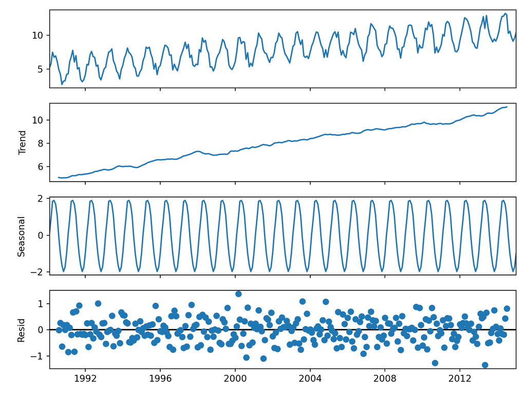

# Time Series Difference Operators

Is there an alternative for dealing with trend?

How do we deal with random walks?

- **Difference operators** are useful for both cases
- Difference operators return the innovations

$$\nabla y_t = y_t - y_{t-\delta}$$
Where $\delta =$ the time difference

# Time Series Difference Operators

Difference operators return the innovations

$$\nabla y_t = y_t -
y_{t-\delta}$$

- Difference operators can be of any order in principle
  - Typically use first order differences
- Differences can be non-seasonal or seasonal
  - Non-seasonal first order difference; $\delta = 1$
  - Seasonal first order difference; $\delta = p$, $p =$ period of seasonality
- Difference operator with $\delta = n$ computes a series $n$ shorter than original

# Time Series Difference Operators

Example of a first order difference operator applied to random walk

- The innovations look random
- Need to verify statistical properties

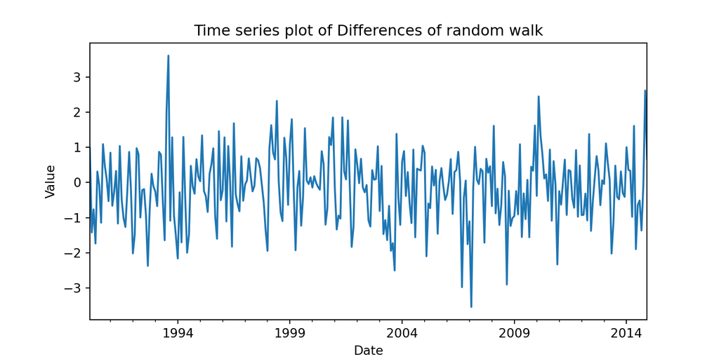

# Time Series Difference Operators

Statistical properties of the difference series

- Compute the ACF and PACF
- The plots indicate the difference series is white noise

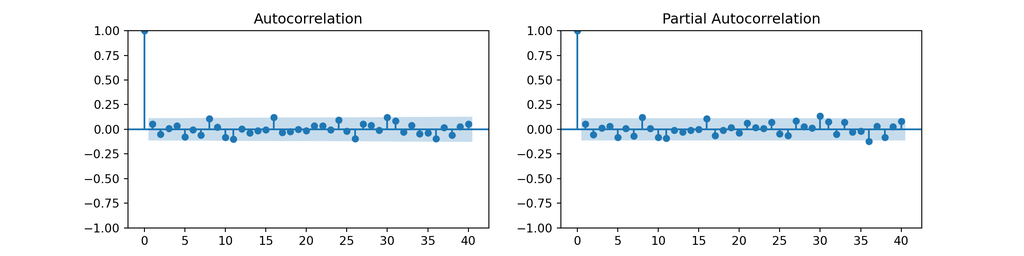

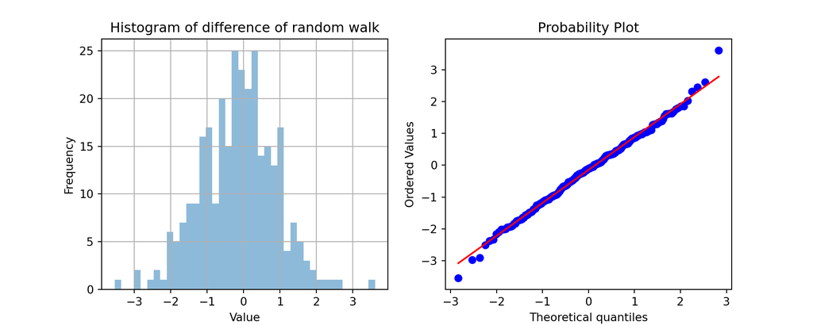

# Stationarity

A **Stationary time series has statistical properties that are invariant in time**

Conversely, a time series is not stationary if it has any of the following properties:  
1. Random walk.  
2. Trend.  
3. Seasonality.  
4. Non-constant variance.

Note, a stationary series does not preclude the presence of serial correlations  
- Do not confuse these points!  
- Many time series models for serial correlation properties require stationarity

# Stationarity

A simple model for a time series process with white noise can be written:

$$\begin{align}
y_t &= \phi y_{t-1} + w_t\\
w_t &\sim \mathbb{N}(0,\sigma)
\end{align}$$

- Example of an **autoregressive model**, where thevalue at the next time step depends on the current value
- The change from time $t-1$ to time $t$ can easily be worked out by taking the differences:

$$\Delta y_t = (1- \phi) y_{t-1} +
w_t$$

# Stationarity

The change from time $t-1$ to time $t$ can easily be worked out by taking the differences:

$$\Delta y_t = (1- \phi) y_{t-1} +
w_t$$

- Foregoing has a root at $\phi = 1$, know as the **unit root**
- At the root the difference between $y_t$ and $y_{t-1}$ is just $w_t$
- Gives rise to a random walk, which is stochastic and **not stationary**:

$$y_t = \sum_{i=1}^t w_i$$

# Stationarity

A random walk is stochastic and **not stationary**:

$$y_t = \sum_{i=1}^t w_i$$

- Provides a basis for hypothesis tests of stationarity
- Test the hypothesis that there is a unit root to determine is a time series is stationary

# Stationarity

There are several ways to define a model for a stationary process:

1. A **unit root test** as discussed

$$y_t = \phi y_{t-1} + w_t$$

2. A **unit root test with a constant**
   - Often constant is initial value, $c=y_0$
   - Or a mean value

$$y_t = c + \phi y_{t-1} +
w_t$$

3. **Trend stationary process**, with or without a constant
   - Used to test if a process is **stationary about a deterministic trend**, $\beta$.

$$y_t = c + \beta t + \phi y_{t-1} +
w_t$$

# Stationarity

There are a number of ways to determine if a time series is stationary.

We will work with two of the many possible tests here:

1. [**Augmented Dicky-Fuller test**](https://en.wikipedia.org/wiki/Augmented_Dickey%E2%80%93Fuller_test) or **ADF** test
   - ADF tests are unit root tests of the significance a linear time series model
   - Coefficients represent components of the time series, e.g. trend and lagged differences
   - Null distribution is that the series is non-stationary
2. [**Kwiatkowski–Phillips–Schmidt–Shin (KPSS) test**](https://en.wikipedia.org/wiki/KPSS_test) is a unit root test for stationarity about a trend of time series
   - Null hypothesis is that the time series is trend stationary

# Stationarity

There is often a small difference between a time series with a unit root, which is non-stationary, and a time series with a root close to unit

- Therefore, unit root tests are said to **lack power**
- Lack of power means a hypothesis test may not be able to reject a hypothesis of non-stationary
- In other cases, the opposite might be true
- It is best to perform a visual inspection of the properties of the time series as well

# Time Series Forecasting Models

**Forecasting** is the goal of much of time series analysis

# The ARIMA and SARIMAX Model

The **ARIMA model** is composed three components:

- **Autoregressive component (AR)** accounts for partial autocorrelation
  - Serial correlation of observatons
- **Integrative component (I)** accounts random walks and trend
- **Moving Average (MA)** accounts for autocorrelation
  - Serial correlation of model error
- **SARIMAX** model adds:
  - **Seasonal components (S)**
  - **Exogenous variables (X)**

# The Autoregressive Model

**Autoregressive model** relates past observed values to the current value

- An autoregressive model of order $p$, $AR(p)$, uses the last p observations:

$$\begin{align}
x_t &= \phi_1 y_{t-1} + \phi_2 y_{t-2} ,\ldots, \phi_p y_{t-p} +
w_t\\
&where\\
\phi_k &= model\ coefficient\ at\ lag\ k\\
w_t &= white\ noise\ error\ at\ time\ t;\ \sim
\mathtt{N}(0,\sigma^2)\\
y_t &= observation\ at\ time\ t\\
\end{align}$$

- An AR process has the following properties:
  - $\rho_0 = 1$ always
  - $p_k = \phi_k$
  - Number of nonzero PACF values $= p$
  - A shock at any time will affect the result as $t \rightarrow \infty$
- AR model assume stationary time series

# The Autoregressive Model

How can we understand the AR model?

- Consider an AR(2) model
- The value of $y_t$ is a weighted sum of $k$ previous values plus an error term

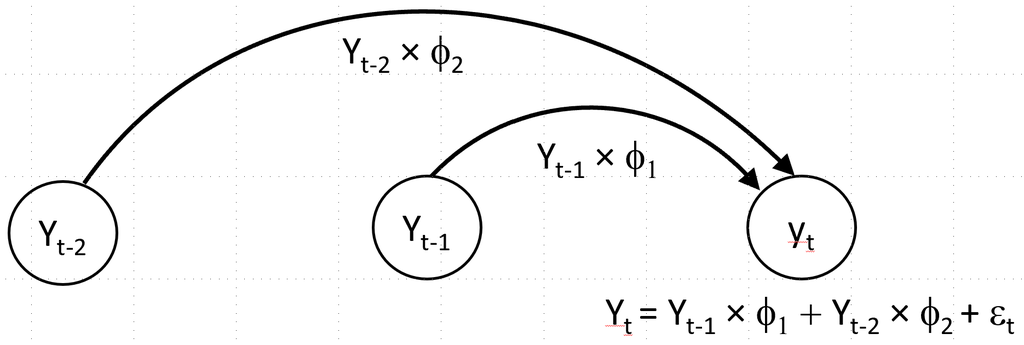

Illustration of the AR(2) model

# The Autoregressive Model

How can we understand the AR model?

- Model matrix of AR(2) model

$$A =
\begin{bmatrix}
y_t,\ y_{1-1},\ y_{t-2}\\
y_{t-1},\ y_{1-2},\ y_{t-3}\\
y_{t-2},\ y_{1-3},\ y_{t-4}\\
\vdots,\ \ \ \ \ \vdots,\ \ \ \ \ \vdots\\
y_{2},\ \ \ \ y_{1},\ \ \ \ y_{0}\\
y_{1},\ \ \ \ y_{0}\ \ \ \, 0\\
y_0,\ \ \ \ 0,\ \ \ \ 0
\end{bmatrix}$$

- AR model is a **linear model!**
- For coefficient vector, $\Phi = [\phi_1, \phi_2, \ldots, \phi_p]$, solve linear system:

$$Y = A \Phi$$

# The Autoregressive Model

We can rewrite the AR(1) model in terms of exceptions:

$$y_t = \sum_{i=1}^t w_i$$

# The Autoregressive Model

- Time series looks a bit random
- But, notice the statistical properties; ACF, PACF
- PACF has 2 non-zero lag values, so $p=2$

```
## Is the time series stationary? True
## Is the time series invertable? True
```

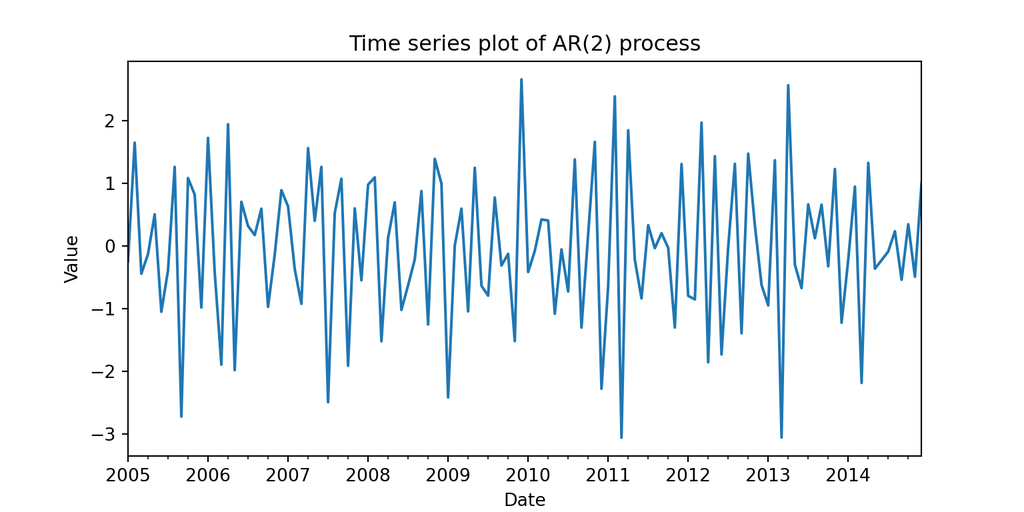

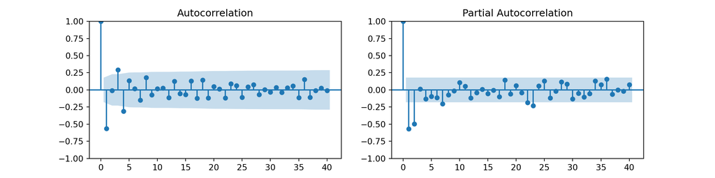

# The Autoregressive Model

Example model summary for AR(2) model:

- Both AR coefficients are statistically significant
- Variance term is statistically significant

```
##                                SARIMAX Results
## ==============================================================================
## Dep. Variable:                      y   No. Observations:                  120
## Model:                 ARIMA(2, 0, 0)   Log Likelihood                -152.398
## Date:                Mon, 06 Nov 2023   AIC                            312.795
## Time:                        07:38:38   BIC                            323.945
## Sample:                    01-31-2005   HQIC                           317.323
##                          - 12-31-2014
## Covariance Type:                  opg
## ==============================================================================
##                  coef    std err          z      P>|z|      [0.025      0.975]
## ------------------------------------------------------------------------------
## const         -0.0299      0.035     -0.862      0.389      -0.098       0.038
## ar.L1         -0.8445      0.079    -10.688      0.000      -0.999      -0.690
## ar.L2         -0.4922      0.091     -5.419      0.000      -0.670      -0.314
## sigma2         0.7366      0.105      7.021      0.000       0.531       0.942
## ===================================================================================
## Ljung-Box (L1) (Q):                   0.00   Jarque-Bera (JB):                 0.32
## Prob(Q):                              0.98   Prob(JB):                         0.85
## Heteroskedasticity (H):               0.69   Skew:                            -0.06
## Prob(H) (two-sided):                  0.24   Kurtosis:                         2.77
## ===================================================================================
##
## Warnings:
## [1] Covariance matrix calculated using the outer product of gradients (complex-step).
```

# The Moving Average Model

A **moving average** model of order $q$, $MA(q)$, uses the last q error terms or shocks:

$$\begin{align}
y_t &= \mu + \epsilon_t + \theta_1 \epsilon_{t-1} + \theta_2
\epsilon_{t-2} + \cdots + \theta_q \epsilon_{t-q}\\
&where\\
\theta_k &= model\ coefficient\ at\ lag\ k\\
y_t &= observation\ at\ time\ t\\
\epsilon_t &= innovation\ or\ error\ at\ time\ t;\ \sim
\mathtt{N}(0,\sigma^2)
\end{align}$$

- An MA process has the following properties:
  - For autocorrelation, $\rho_0 = 1$ always
  - Number of $\rho_k \ne 0$, $= q$, $k \gt 0$
  - Shocks die off quickly in MA processes
- MA model assumes stationary time series

# The Moving Average Model

A **moving average** model of order $q$, $MA(q)$, uses the last q error terms or shocks:

$$y_t = \mu + \epsilon_t + \theta_1
\epsilon_{t-1} + \theta_2 \epsilon_{t-2} + \cdots + \theta_q
\epsilon_{t-q}$$

We can also write the MA model in terms of estimated value, $\hat{y}_t$:

$$\begin{align}
\hat{y}_t &= c + \theta_1 \epsilon_{t-1} + \theta_2 \epsilon_{t-2} +
\cdots + \theta_q \epsilon_{t-q}\\
& Therefore,\\
\epsilon_t &= y_t - \hat{y}_t \sim \mathtt{N}(0,\sigma^2);\ error\
at\ time\ t \\
\end{align}$$

# The Moving Average Model

How can we understand the MA model?

- Model matrix of MA(2) model

$$A =
\begin{bmatrix}
y_t,\ \epsilon_{1-1},\ \epsilon_{t-2}\\
y_{t-1},\ \epsilon_{1-2},\ \epsilon_{t-3}\\
y_{t-2},\ \epsilon_{1-3},\ \epsilon_{t-4}\\
\vdots,\ \ \ \ \ \vdots,\ \ \ \ \ \vdots\\
y_{2},\ \ \ \ \epsilon_{1},\ \ \ \ \epsilon_{0}\\
y_{1},\ \ \ \ \epsilon_{0}\ \ \ \, 0\\
y_0,\ \ \ \ 0,\ \ \ \ 0
\end{bmatrix}$$

- MA model is a **nonlinear model!**; must compute $\epsilon_{t}$ at each time step
- The value of $\epsilon_t$ dependents on $[ \epsilon_{t-1}, \epsilon_{t-2}, ..., \epsilon_{t-q}]$
- The $\epsilon_k$s are **unobservable**!
- So, fitting requires **nonlinear iteratively rewieighted least squares**

# The Moving Average Model

Example of an MA(1) model with coefficients $(1, -0.75)$

- The time series looks fairly random
- The ACF has 1 statistically significant nonzero lag value

```
## Is the time series stationary? True
## Is the time series invertable? True
```

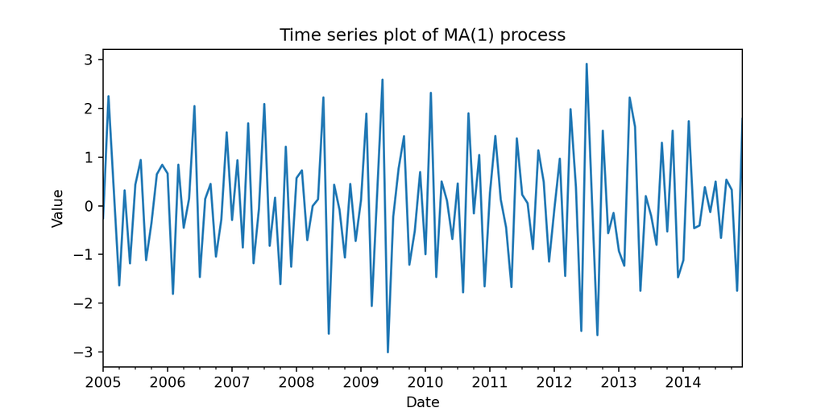

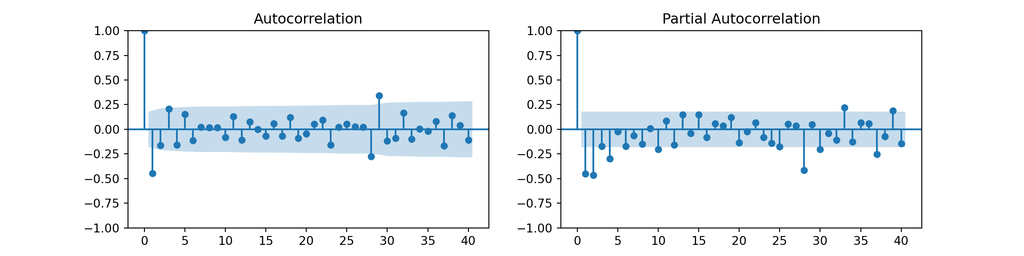

# The Moving Average Model

Example model summary for MA(1) model:

- The MA coefficient is statistically significant
- Notice that true value is within the confidence interval
- Confidence interval is wide

```
##                                SARIMAX Results
## ==============================================================================
## Dep. Variable:                      y   No. Observations:                  120
## Model:                 ARIMA(0, 0, 1)   Log Likelihood                -162.751
## Date:                Mon, 06 Nov 2023   AIC                            331.502
## Time:                        07:38:39   BIC                            339.864
## Sample:                    01-31-2005   HQIC                           334.898
##                          - 12-31-2014
## Covariance Type:                  opg
## ==============================================================================
##                  coef    std err          z      P>|z|      [0.025      0.975]
## ------------------------------------------------------------------------------
## const          0.0214      0.015      1.395      0.163      -0.009       0.051
## ma.L1         -0.8303      0.049    -17.024      0.000      -0.926      -0.735
## sigma2         0.8736      0.126      6.936      0.000       0.627       1.120
## ===================================================================================
## Ljung-Box (L1) (Q):                   0.11   Jarque-Bera (JB):                 1.59
## Prob(Q):                              0.74   Prob(JB):                         0.45
## Heteroskedasticity (H):               1.12   Skew:                             0.21
## Prob(H) (two-sided):                  0.71   Kurtosis:                         2.63
## ===================================================================================
##
## Warnings:
## [1] Covariance matrix calculated using the outer product of gradients (complex-step).
```

# Autoregressive Moving Average Model

We can combine AR and MA terms to create the **autoregressive moving average (ARMA)** model of order $(p,q)$:

$$y_t = \phi_1 y_{t-1} + \phi_2 y_{t-2}
,\ldots, + \phi_p y_{t-p} +
\epsilon_t + \theta_1 \epsilon_{t-1} + \theta_2 \epsilon_{t-2} + \cdots
+ \theta_q \epsilon_{t-q}$$

- Fit ARMA model by solving a nonlinear equatioin:

$$y_t - \phi_1 y_{t-1} - \phi_2 y_{t-2}
,\ldots, - \phi_p y_{t-p} =
\epsilon_t + \theta_1 \epsilon_{t-1} + \theta_2 \epsilon_{t-2} + \cdots
+ \theta_q \epsilon_{t-q}$$

- Can write as polynomial equation in terms of coefficient vectors $\Phi = [1, \phi_1, \phi_2, \ldots, \phi_p y]$, $\Theta = [1, \theta_1, \theta_2, \cdots, \theta_q]$:
  $$(1-\Phi)Y = \Theta
  \epsilon$$
- ARMA model assumes stationary time series

# The ARIMA Model

The integrative model addresses certain non-stationary components of a time series

- Random walks
- Trends
- Based on difference operator
  - Typically first order difference
  - Seasonal and non-seasonal differences
  - Is deterministic, no model coefficient to estimate

# The ARIMA Model

The **autoregressive integrative moving average (ARIMA)** model includes AR, integrative and MA terms

- The order of an ARIMA is specified as (p,d,q)
  - p is the AR order
  - d is the order of differencing
  - q is the MA order
- The integrative term helps transforms trend and random walks to stationary process
- Does not account for seasonal effect

# The ARIMA Model

The **autoregressive integrative moving average (ARIMA)** model includes AR, integrative and MA terms

- Formulate an $ARIMA(1,1,1)$ model
- Start with $ARMA(1,1) = ARIMA(1,0,1)$ model:

$$y_t - c - \phi_1 y_{t-1} = \epsilon_t
+ \theta_1 \epsilon_{t-1}$$

- Take the first difference of the observations, $y_i$, to find the formulation of the $ARIMA(1,1,1)$ model.

$$y_t - y_{t-1} - \phi_1( y_{t-1} -
y_{t-2}) = \epsilon_t + \theta_1 \epsilon_{t-1}$$

- Applied same algebra to finding polynomial formulations for higher order ARIMA models.

# Seasonal Models

Several possible seasonal models

- Seasonal effects can be periodic or single event (e.g. holiday, game day, etc.)
- Linear regression model to find effect for each time step in period
- STL decomposition
- Fourier decomposition
  - Flexible and accomodates multiple periods of seasonality
  - Used by PROFIT model, [Statsmodels](https://www.statsmodels.org/dev/examples/notebooks/generated/statespace_seasonal.html) and others
- SARIMAX, the S term
- Each model requires:
  - Known period of the cycle or time of seasonal event
  - Additive or logarithmic transformation

# SARIMAX Model

The SARIMAX model adds seasonal and exogenous terms

- ARIMA terms are same, (p,d,q)
- Seasonal terms:
  - ARIMA model, order (P,D,Q,S)
  - Must specify period, S
- Order of SARIMAX model is specified as (p,d,q)(P,D,Q,S)
- See [Statsmodels State Space User Guide](https://www.statsmodels.org/dev/examples/notebooks/generated/statespace_sarimax_stata.html) for more details and examples

# SARIMAX Model

SARIMA model can be formulated as an additive or a multiplicative model of the components of a non-seasonal ARIMA model and the seasonal ARIMA model

- Additive model can be expressed: $SARIMA \big[ (p,d,q) + (P,D,Q)_M \big]$
- Multiplicative model can be expressed: $SARIMA \big[ (p,d,q)(P,D,Q)_M \big]$
- Example, a multiplicative $SARIMA(1,1,1)(1,1,1)_M$ model:

$$(y_t - \phi_1 y_{t-1})(y_t - \Phi_1
y_{t-M})(1-y_{t-1})(y_t - y_{t-M}) = (\epsilon_t - \theta_1
\epsilon_{t-1})(\epsilon_t - \Theta_1 \epsilon_{t-M})$$

- Continuesame algebra to find the polynomial of any $(p,d,q)(P,D,Q)$ order
- Create a recurssion to forecast future values as shown before

# SARIMAX Model

The SARIMAX model (with no exogenous variables) is formulated

$$\phi_p(Y) \tilde{\phi}_P(Y^*) \nabla^d \nabla^D y_t = A(t) +
\theta_q(Y) \tilde{\theta}_Q(Y^*)$$

- $\phi_p(Y)$ and $\tilde{\phi}_P(Y^*)$ are the AR polynomials non-seasonal and seasonal terms
- $\theta_q(Y)$ and $\tilde{\theta}_Q(Y^*)$ are the MA polynomials non-seasonal and seasonal terms
- $\nabla^d$ and $\nabla^D$ are the non-seasonal and seasonal differencing operators
- $A(t)$ is the trend term

# SARIMAX Model

SARIMAX model can include exogenous variables, $x$, leading to a new system of equations”:

$$y_t = \beta_t x_t + \mu_t \\
\phi_p(Y) \tilde{\phi}_P(Y^*) \nabla^d \nabla^D \mu_t = A(t) +
\theta_p(Y) \tilde{\theta}_P(Y^*)$$

- Time series model for latent variable, $\mu_t$
- $\mu_t$ acts as the intercept term for the regression model for $x_t$
- The coefficient vector, $\beta$, contains the **effect sizes** for the exogenous variables

# Forecasting with the ARIMA model

Goal of forecasting is to compute a point estimates, $\hat{y}_{t+H}$, $H$ time steps in the future

- Use the time series history, $[y_t, y_{t-1}, y_{t-2}, \ldots]$
- Example, compute a forecast for a stationary time series with an $ARIMA(p,d,q)$ model
- Recursively apply a one step ahead forecast
- For the forecasted value $\hat{y}_{t+H}$ we have no estimated error:

$$\epsilon_{t+H} = y_{t+H} -
\hat{y}_{t+H}$$

# Forecasting with the ARIMA model

Goal of forecasting is to compute a point estimates, $\hat{y}_{t+H}$, $H$ time steps in the future

- Example, make a forecast with an ARIMA(2,1,1) model:

$$y_t - y_{t-1} - \phi_1( y_{t-1} -
y_{t-2}) - \phi_2 ( y_{t-2} - y_{t-3}) = \epsilon_t + \theta_1
\epsilon_{t-1}$$

- Model the one step ahead forecast as:

$$\hat{y}_{t+1}= y_{t} - \phi_1( y_{t} -
y_{t-1}) - \phi_1( y_{t-1} - y_{t-2}) + \theta_1 \epsilon_{t} +
\epsilon_{t+1}$$

- Two step ahead forecast is computed using a recursive relationship

# Forecasting with the ARIMA model

Two step ahead forecast is computed using a recursive relationship

- But, no way to compute the error terms beyond the current observation at time $t$
- Replace $\epsilon_{t+1}$ with the last known residual as $e_{t+2} = e_t$:

$$\hat{y}_{t+2}= \hat{y}_{t+1} - \phi_1(
\hat{y}_{t+1} - y_{t}) - \phi_1( y_{t} - y_{t-1}) + \theta_1
e_{t}$$

- Take recursion one more step, set error terms, $\epsilon_i = 0$:

$$\hat{y}_{t+3}= \hat{y}_{t+2} - \phi_1(
\hat{y}_{t+2} - y_{t+1}) - \phi_1( y_{t+1} - y_{t})$$

- Continue this recursion for as many time steps as desired
- Same algebra used to work out the forecasting axolynomial of higher order ARIMA model

# Evaluating and Comparing Time Series Models

How can we evaluate time series models?

- RMSE; compare forecast to actual values
- Could use log-likelihood; $log \big(p(X|\theta) \big)$
  - $\theta = model\ parameters$
  - Use **score function** $= -2\ log(likelihood) = -2\ log \big(p(X|\theta) \big)$
- But, score will decrease with model complexity
- Need to adjust for number of model parameters
  - We always prefer simpler models; fewer parameters to learn
  - **Akaki Information Criteria (AIC)**
  - **Bayes Information Criteria (BIC)**

# Evaluating and Comparing Time Series Models

Akaki Information criteria, AIC

$$\begin{align}
AIC &= 2\ k - 2\ ln(\hat{L})\\
&where\\
\hat{L} &= the\ likelihood\ given\ the\ fitted\ model\ parmaters\
\hat\theta = p(x| \hat\theta)\\
x &= observed\ data\\
k &= number\ of\ model\ parameters
\end{align}$$

- AIC penalizes the score function for the complexity of the model by $2\ k$
- Model with lowest AIC is best

# Evaluating and Comparing Time Series Models

Bayes Information criteria, BIC

$$\begin{align}
BIC &= ln(n)\ k- 2\ ln(\hat{L})\\
&where\\
\hat{L} &= the\ likelihood\ given\ the\ fitted\ model\ parmaters\
\hat\theta = p(x| \hat\theta)\\
x &= observed\ data\\
k &= number\ of\ model\ parameters\\
n &= number\ of\ observations
\end{align}$$

- BIC penalizes the score function for the complexity of the model, $k$
- BIC adjusts for number of samples used to learn the $k$ model parameters
- Model with lowest BIC is best
- BIC is often preferred to AIC for time series models

# Evaluating and Comparing Time Series Models

Can compare and select models using BIC or AIC

- Backwards step-wise model selection
  1. Start with initial order of the model; e.g. $(p,d,q)(P,D,Q,S)$
  2. Fit (learn) the model parameters
  3. compute the BIC, and if reduced consider this a better model
  4. Reduce the order of one of the model components
  5. Repeat steps 2, 3 and 4 until no further improvement
- Tips for comparing models:
  - BIC and AIC are approximations; small changes (3rd or 4th decimal) are not important
  - If close tie for best model pick the simpler (lower order) case
  - Often best to consider integrative terms, $d$ and $D$, separately

# SARIMAX Example

Example: 3 time series of Australian production

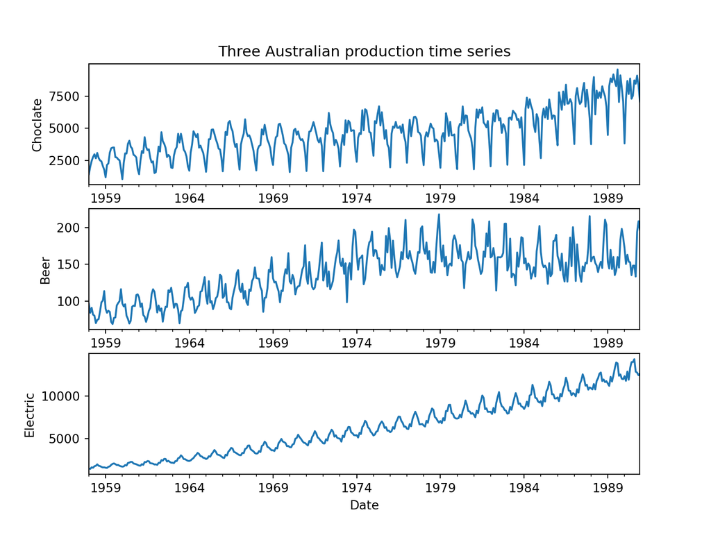

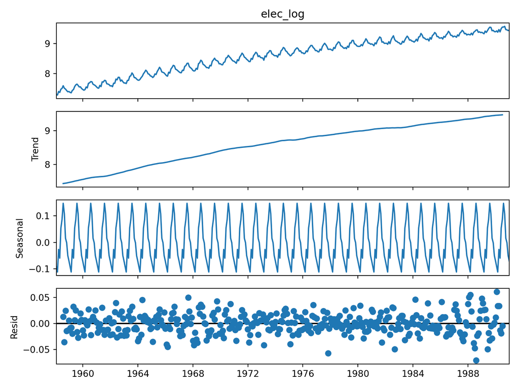

# SARIMAX Example

Use the SARIMAX model to find the best ARIMA fit of log(electric production)

```python
Log_electric = CBE.elec_log[:'1989-12-31']
best_model = pm.auto_arima(Log_electric, start_p=1, start_q=1,
                             max_p=3, max_q=3, m=12,
                             start_P=0, seasonal=True,
                             d=1, D=1, trace=True,
                             information_criterion = 'bic',
                             error_action='ignore',  # don't want to know if an order does not work
                             suppress_warnings=True,  # don't want convergence warnings
                             stepwise=True)  # set to stepwise
```

```
## Performing stepwise search to minimize bic
##  ARIMA(1,1,1)(0,1,1)[12]             : BIC=-1794.344, Time=0.90 sec
##  ARIMA(0,1,0)(0,1,0)[12]             : BIC=-1572.064, Time=0.17 sec
##  ARIMA(1,1,0)(1,1,0)[12]             : BIC=-1696.328, Time=0.68 sec
##  ARIMA(0,1,1)(0,1,1)[12]             : BIC=-1800.249, Time=0.52 sec
##  ARIMA(0,1,1)(0,1,0)[12]             : BIC=-1699.081, Time=0.11 sec
##  ARIMA(0,1,1)(1,1,1)[12]             : BIC=-1800.515, Time=0.88 sec
##  ARIMA(0,1,1)(1,1,0)[12]             : BIC=-1742.451, Time=0.28 sec
##  ARIMA(0,1,1)(2,1,1)[12]             : BIC=-1797.600, Time=2.11 sec
##  ARIMA(0,1,1)(1,1,2)[12]             : BIC=-1796.438, Time=2.55 sec
##  ARIMA(0,1,1)(0,1,2)[12]             : BIC=-1802.021, Time=2.05 sec
##  ARIMA(0,1,0)(0,1,2)[12]             : BIC=inf, Time=0.76 sec
##  ARIMA(1,1,1)(0,1,2)[12]             : BIC=-1796.168, Time=2.89 sec
##  ARIMA(0,1,2)(0,1,2)[12]             : BIC=-1795.957, Time=3.01 sec
##  ARIMA(1,1,0)(0,1,2)[12]             : BIC=-1770.768, Time=2.53 sec
##  ARIMA(1,1,2)(0,1,2)[12]             : BIC=-1790.196, Time=3.35 sec
##  ARIMA(0,1,1)(0,1,2)[12] intercept   : BIC=inf, Time=1.10 sec
##
## Best model:  ARIMA(0,1,1)(0,1,2)[12]
## Total fit time: 23.896 seconds
```

# SARIMAX Example

Example of SARIMAX model of order (0.1.1)(0,1,2,12) for monthly electric production series

```
## <class 'statsmodels.iolib.summary.Summary'>
## """
##                                         SARIMAX Results
## ===============================================================================================
## Dep. Variable:                                       y   No. Observations:                  384
## Model:             SARIMAX(0, 1, 1)x(0, 1, [1, 2], 12)   Log Likelihood                 912.843
## Date:                                 Mon, 06 Nov 2023   AIC                          -1817.686
## Time:                                         07:39:06   BIC                          -1802.021
## Sample:                                     01-31-1958   HQIC                         -1811.464
##                                           - 12-31-1989
## Covariance Type:                                   opg
## ==============================================================================
##                  coef    std err          z      P>|z|      [0.025      0.975]
## ------------------------------------------------------------------------------
## ma.L1         -0.6346      0.039    -16.351      0.000      -0.711      -0.559
## ma.S.L12      -0.5898      0.061     -9.594      0.000      -0.710      -0.469
## ma.S.L24      -0.1575      0.062     -2.546      0.011      -0.279      -0.036
## sigma2         0.0004   2.63e-05     15.827      0.000       0.000       0.000
## ===================================================================================
## Ljung-Box (L1) (Q):                   0.01   Jarque-Bera (JB):                10.93
## Prob(Q):                              0.93   Prob(JB):                         0.00
## Heteroskedasticity (H):               1.02   Skew:                            -0.23
## Prob(H) (two-sided):                  0.90   Kurtosis:                         3.71
## ===================================================================================
##
## Warnings:
## [1] Covariance matrix calculated using the outer product of gradients (complex-step).
## """
```

# SARIMAX Example

Predictions for the last 12 months of the time series

```python
prediction = pd.Series(best_model.predict(n_periods=12),
                       index = pd.date_range(start = '1990-01-31', end = '1990-12-31', freq = 'M'))
```

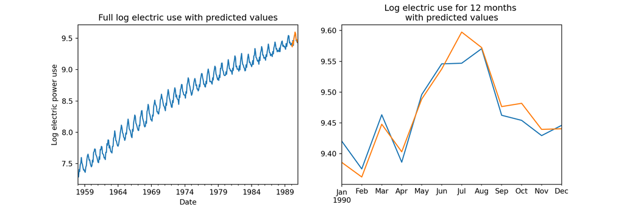

# SARIMAX Example

Residuals of the predictions

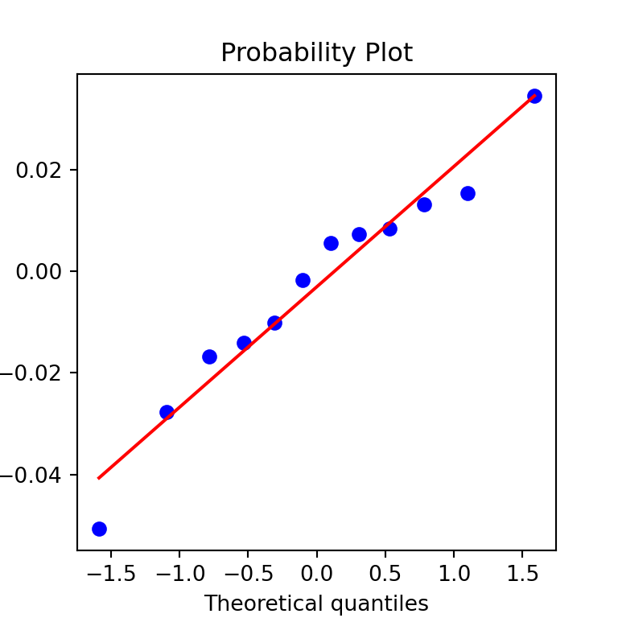

```python
residuals = CBE.elec_log['1990-01-31':] - prediction

fig, ax = plt.subplots(nrows=1, ncols=1, figsize=(4, 4))
_=ss.probplot(residuals, plot = ax);
plt.show()
```

# Summary

Fundamental elements of time series

- Fundamental components which cannot be predicted
  - White noise
  - Random walks
- Autocorrelation and partial autocorrelation
- Trend
- Seasonal components
- Stationarity properties; Dicky Fuller test

# Summary

Time series models must account for serial correlation

- Exponential models; e.g. Holt-Winters
- Second order accounts for trend
- Third order accounts for trend and seasonal

# Summary

Time series models must account for serial correlation

- e.g. ARIMA and SARIMAX
- AR components for serial correlation of values
- MA components for serial correlation of errors
- Integrative components for random walk and trend, I
- Seasonal, (P,D,Q,S)
- Exogenous variables, X

# Summary

Evaluation and model comparison

- RMSE
- AIC and BIC, penalize score function for model complexity
- Use BIC (or AIC) to perform backwards step-wise model selection

## Exponential Smoothing Models

[Exponential smoothing models](https://en.wikipedia.org/wiki/Exponential_smoothing) are simple and widely used

- Consider the simple first order model
- Set initial conditions:

$$s_0 = y_0$$

- The smoothed update is:

$$s_t = \alpha y_t + (1-\alpha) s_{t-1}\\
= s_{t-1} \alpha(y_t - s_{t-1}),\\
t \gt 0$$

- And, the smoothing coefficient is, $0 \le \alpha \le 1$
- But, model only works if no trend

# Exponential Smoothing Models

Decay and exponential smoothing

- We can understand the smoothing parameter $\alpha$ in terms of a **decay constant**, $\tau$

$$\alpha = 1 - e^{\big( \frac{\Delta
T}{\tau} \big)}$$

- An innovation or shock has an effect for all future time
- Effect decays exponentially with time, $\Delta T$

# Exponential Smoothing Models

Can extend exponential smoothing model to accommodate trend

- Algorithm known as **double exponential smoothing** or **Holt-Winters double exponential smoothing**
- Update smoothed values and slope at each time step
- Start with initial values

$$s_1 = y_1\\
b_1 = y_2 - y_1$$

- Update relationships for both smoothed value and slope

$$s_t = \alpha y_t + (1-\alpha) (s_{t-1} +
b_{t-1})\\
b_t = \beta(s_t - s_{t-1}) + (1 - \beta)b_{t-1}$$

- Additional slope smoothing hyperparameter, $0 \le \beta \le 1$
- Use **third order** update includes seasonality in **Holt-Winters smoother**

# Exponential Smoothing Models

Exponential smoothing models are useful for forecasting

- Forecast dependent on the choice of smoothing parameters
- Can forecast with first, second, third order models
- For second order model (with trend) the forecast $m$ steps ahead is:

$$F_{t+m} = s_t + m b_t$$

- Third order update include seasonal terms
- Holt-Winters smoother is a **linear model!**

# Exponential Smoothing Models

Example of smoothing trend plus white noise series

- Decreasing the smoothing parameter, $\alpha$, increases smoothing
- Additionally, smooth trend
- Additional examples in [Statsmodels user documentation](https://www.statsmodels.org/stable/examples/notebooks/generated/exponential_smoothing.html)

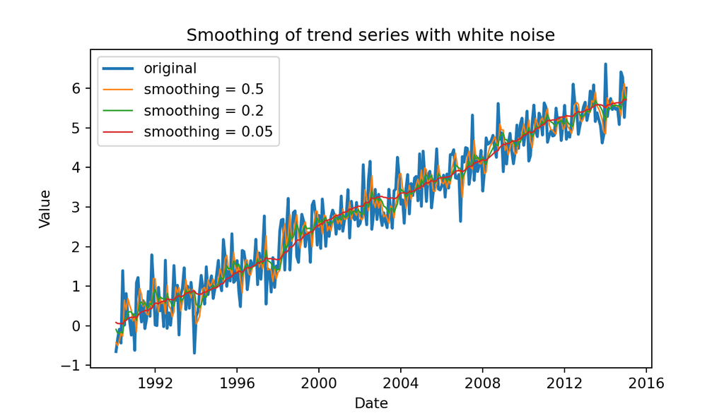